# Air Quality Category Tables

Processed on 2024-02-29 17:11:31 PST.

*Disclaimer: Data presented here come from a variety of sources and do not represent official EPA measurements. Please visit [AirNow](https://www.airnow.gov) for official measurements.*

The following tables summarize the cumulative number of days air quality monitors spent in each AQI category during wildfire season.

The ‘Old’ table and barplot are calculated using the 2023 PM<sub>2.5</sub> NAAQS while the ‘New’ table and barplot are calculated using the 2024 PM<sub>2.5</sub> NAAQS.

# 2012

**Using Old (2023) PM<sub>2.5</sub> NAAQS**

|  | Good | Moderate | USG | Unhealthy | Very Unhealthy | Hazardous | Missing |
| --- | --- | --- | --- | --- | --- | --- | --- |
| Wenatchee | 18 | 5 | 6 | 5 | 1 | 1 | 86 |
| Leavenworth | 94 | 15 | 4 | 9 | 0 | 0 | 0 |
| Twisp | 97 | 12 | 4 | 5 | 0 | 0 | 4 |
| Winthrop | 99 | 14 | 7 | 2 | 0 | 0 | 0 |
| Omak | 102 | 18 | 1 | 1 | 0 | 0 | 0 |

**Using New (2024) PM<sub>2.5</sub> NAAQS**

|  | Good | Moderate | USG | Unhealthy | Very Unhealthy | Hazardous | Missing |
| --- | --- | --- | --- | --- | --- | --- | --- |
| Wenatchee | 13 | 10 | 6 | 5 | 1 | 1 | 86 |
| Leavenworth | 84 | 25 | 4 | 9 | 0 | 0 | 0 |
| Twisp | 81 | 28 | 4 | 5 | 0 | 0 | 4 |
| Winthrop | 88 | 25 | 6 | 3 | 0 | 0 | 0 |
| Omak | 87 | 33 | 1 | 1 | 0 | 0 | 0 |

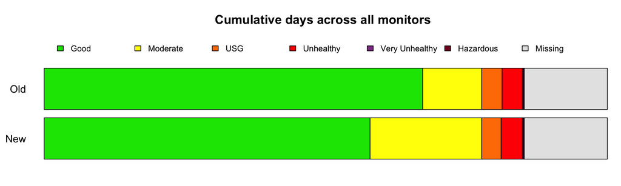

# 2013

**Using Old (2023) PM<sub>2.5</sub> NAAQS**

|  | Good | Moderate | USG | Unhealthy | Very Unhealthy | Hazardous | Missing |
| --- | --- | --- | --- | --- | --- | --- | --- |
| Wenatchee | 49 | 6 | 0 | 0 | 0 | 0 | 68 |
| Leavenworth | 108 | 11 | 0 | 0 | 0 | 0 | 4 |
| Twisp | 112 | 9 | 0 | 0 | 0 | 0 | 2 |
| Winthrop | 111 | 7 | 0 | 0 | 0 | 0 | 5 |
| Omak | 65 | 17 | 0 | 0 | 0 | 0 | 41 |

**Using New (2024) PM<sub>2.5</sub> NAAQS**

|  | Good | Moderate | USG | Unhealthy | Very Unhealthy | Hazardous | Missing |
| --- | --- | --- | --- | --- | --- | --- | --- |
| Wenatchee | 45 | 10 | 0 | 0 | 0 | 0 | 68 |
| Leavenworth | 94 | 25 | 0 | 0 | 0 | 0 | 4 |
| Twisp | 97 | 24 | 0 | 0 | 0 | 0 | 2 |
| Winthrop | 96 | 22 | 0 | 0 | 0 | 0 | 5 |
| Omak | 56 | 26 | 0 | 0 | 0 | 0 | 41 |

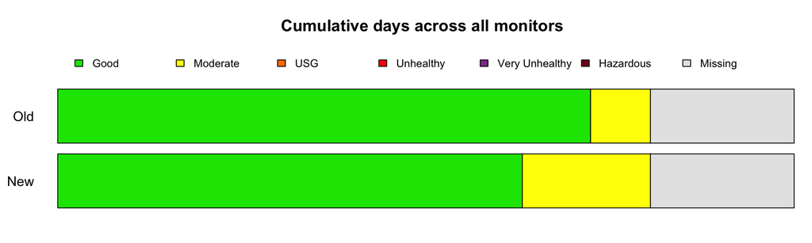

# 2014

**Using Old (2023) PM<sub>2.5</sub> NAAQS**

|  | Good | Moderate | USG | Unhealthy | Very Unhealthy | Hazardous | Missing |
| --- | --- | --- | --- | --- | --- | --- | --- |
| Wenatchee | 90 | 19 | 1 | 2 | 0 | 0 | 10 |
| Leavenworth | 74 | 25 | 6 | 0 | 0 | 0 | 17 |
| Twisp | 93 | 16 | 2 | 2 | 0 | 0 | 9 |
| Winthrop | 78 | 12 | 1 | 0 | 0 | 0 | 31 |
| Omak | 49 | 17 | 0 | 0 | 0 | 0 | 56 |

**Using New (2024) PM<sub>2.5</sub> NAAQS**

|  | Good | Moderate | USG | Unhealthy | Very Unhealthy | Hazardous | Missing |
| --- | --- | --- | --- | --- | --- | --- | --- |
| Wenatchee | 83 | 26 | 1 | 2 | 0 | 0 | 10 |
| Leavenworth | 66 | 32 | 7 | 0 | 0 | 0 | 17 |
| Twisp | 76 | 33 | 2 | 2 | 0 | 0 | 9 |
| Winthrop | 68 | 22 | 1 | 0 | 0 | 0 | 31 |
| Omak | 39 | 27 | 0 | 0 | 0 | 0 | 56 |

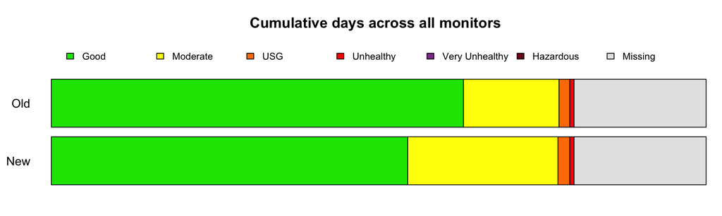

# 2015

**Using Old (2023) PM<sub>2.5</sub> NAAQS**

|  | Good | Moderate | USG | Unhealthy | Very Unhealthy | Hazardous | Missing |
| --- | --- | --- | --- | --- | --- | --- | --- |
| Wenatchee | 90 | 7 | 1 | 0 | 0 | 0 | 24 |
| Leavenworth | 102 | 17 | 3 | 0 | 0 | 0 | 0 |
| Twisp | 77 | 26 | 1 | 8 | 0 | 0 | 10 |
| Winthrop | 53 | 10 | 0 | 0 | 0 | 0 | 59 |
| Omak | 68 | 31 | 5 | 4 | 2 | 5 | 7 |

**Using New (2024) PM<sub>2.5</sub> NAAQS**

|  | Good | Moderate | USG | Unhealthy | Very Unhealthy | Hazardous | Missing |
| --- | --- | --- | --- | --- | --- | --- | --- |
| Wenatchee | 84 | 13 | 1 | 0 | 0 | 0 | 24 |
| Leavenworth | 92 | 27 | 3 | 0 | 0 | 0 | 0 |
| Twisp | 63 | 40 | 1 | 5 | 3 | 0 | 10 |
| Winthrop | 41 | 22 | 0 | 0 | 0 | 0 | 59 |
| Omak | 55 | 44 | 5 | 4 | 1 | 6 | 7 |

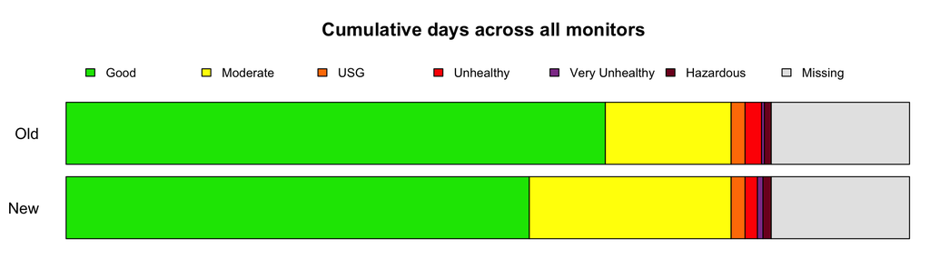

# 2016

**Using Old (2023) PM<sub>2.5</sub> NAAQS**

|  | Good | Moderate | USG | Unhealthy | Very Unhealthy | Hazardous | Missing |
| --- | --- | --- | --- | --- | --- | --- | --- |
| Wenatchee | 81 | 5 | 0 | 0 | 0 | 0 | 36 |
| Leavenworth | 103 | 3 | 0 | 0 | 0 | 0 | 16 |
| Twisp | 121 | 1 | 0 | 0 | 0 | 0 | 0 |
| Winthrop | 98 | 1 | 0 | 0 | 0 | 0 | 23 |
| Omak | 51 | 6 | 0 | 0 | 0 | 0 | 65 |
| Chelan | 55 | 0 | 0 | 0 | 0 | 0 | 67 |

**Using New (2024) PM<sub>2.5</sub> NAAQS**

|  | Good | Moderate | USG | Unhealthy | Very Unhealthy | Hazardous | Missing |
| --- | --- | --- | --- | --- | --- | --- | --- |
| Wenatchee | 78 | 8 | 0 | 0 | 0 | 0 | 36 |
| Leavenworth | 100 | 6 | 0 | 0 | 0 | 0 | 16 |
| Twisp | 116 | 6 | 0 | 0 | 0 | 0 | 0 |
| Winthrop | 95 | 4 | 0 | 0 | 0 | 0 | 23 |
| Omak | 44 | 13 | 0 | 0 | 0 | 0 | 65 |
| Chelan | 55 | 0 | 0 | 0 | 0 | 0 | 67 |

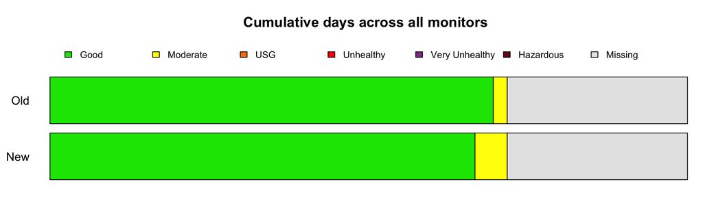

# 2017

**Using Old (2023) PM<sub>2.5</sub> NAAQS**

|  | Good | Moderate | USG | Unhealthy | Very Unhealthy | Hazardous | Missing |
| --- | --- | --- | --- | --- | --- | --- | --- |
| Wenatchee | 83 | 18 | 9 | 9 | 3 | 0 | 0 |
| Leavenworth | 77 | 14 | 1 | 1 | 0 | 0 | 29 |
| Twisp | 79 | 27 | 4 | 12 | 0 | 0 | 0 |
| Winthrop | 82 | 25 | 4 | 11 | 0 | 0 | 0 |
| Omak | 75 | 26 | 4 | 10 | 0 | 0 | 7 |
| Chelan | 85 | 9 | 2 | 1 | 1 | 0 | 24 |

**Using New (2024) PM<sub>2.5</sub> NAAQS**

|  | Good | Moderate | USG | Unhealthy | Very Unhealthy | Hazardous | Missing |
| --- | --- | --- | --- | --- | --- | --- | --- |
| Wenatchee | 73 | 28 | 9 | 9 | 3 | 0 | 0 |
| Leavenworth | 67 | 24 | 1 | 1 | 0 | 0 | 29 |
| Twisp | 69 | 37 | 4 | 12 | 0 | 0 | 0 |
| Winthrop | 68 | 38 | 5 | 11 | 0 | 0 | 0 |
| Omak | 65 | 36 | 3 | 11 | 0 | 0 | 7 |
| Chelan | 80 | 14 | 2 | 0 | 2 | 0 | 24 |

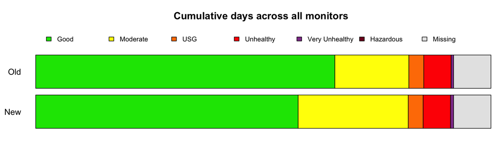

# 2018

**Using Old (2023) PM<sub>2.5</sub> NAAQS**

|  | Good | Moderate | USG | Unhealthy | Very Unhealthy | Hazardous | Missing |
| --- | --- | --- | --- | --- | --- | --- | --- |
| Wenatchee | 83 | 25 | 3 | 7 | 3 | 1 | 0 |
| Leavenworth | 82 | 27 | 1 | 9 | 0 | 0 | 3 |
| Twisp | 55 | 20 | 6 | 23 | 1 | 0 | 17 |
| Winthrop | 75 | 28 | 6 | 12 | 1 | 0 | 0 |
| Omak | 57 | 20 | 3 | 12 | 1 | 1 | 28 |
| Chelan | 77 | 19 | 8 | 10 | 4 | 1 | 3 |

**Using New (2024) PM<sub>2.5</sub> NAAQS**

|  | Good | Moderate | USG | Unhealthy | Very Unhealthy | Hazardous | Missing |
| --- | --- | --- | --- | --- | --- | --- | --- |
| Wenatchee | 74 | 34 | 3 | 6 | 4 | 1 | 0 |
| Leavenworth | 74 | 35 | 1 | 7 | 2 | 0 | 3 |
| Twisp | 47 | 27 | 7 | 21 | 3 | 0 | 17 |
| Winthrop | 67 | 36 | 6 | 11 | 2 | 0 | 0 |
| Omak | 48 | 29 | 3 | 11 | 1 | 2 | 28 |
| Chelan | 70 | 26 | 8 | 8 | 5 | 2 | 3 |

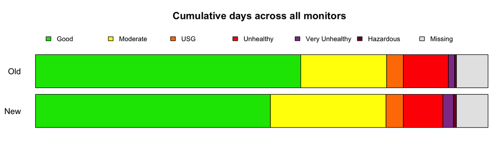

# 2019

**Using Old (2023) PM<sub>2.5</sub> NAAQS**

|  | Good | Moderate | USG | Unhealthy | Very Unhealthy | Hazardous | Missing |
| --- | --- | --- | --- | --- | --- | --- | --- |
| Wenatchee | 117 | 5 | 0 | 0 | 0 | 0 | 0 |
| Leavenworth | 104 | 8 | 0 | 0 | 0 | 0 | 10 |
| Twisp | 107 | 0 | 0 | 0 | 0 | 0 | 15 |
| Winthrop | 120 | 0 | 0 | 0 | 0 | 0 | 2 |
| Omak | 111 | 10 | 0 | 0 | 0 | 0 | 1 |
| Chelan | 117 | 2 | 0 | 0 | 0 | 0 | 3 |

**Using New (2024) PM<sub>2.5</sub> NAAQS**

|  | Good | Moderate | USG | Unhealthy | Very Unhealthy | Hazardous | Missing |
| --- | --- | --- | --- | --- | --- | --- | --- |
| Wenatchee | 109 | 13 | 0 | 0 | 0 | 0 | 0 |
| Leavenworth | 100 | 12 | 0 | 0 | 0 | 0 | 10 |
| Twisp | 98 | 9 | 0 | 0 | 0 | 0 | 15 |
| Winthrop | 114 | 6 | 0 | 0 | 0 | 0 | 2 |
| Omak | 102 | 19 | 0 | 0 | 0 | 0 | 1 |
| Chelan | 112 | 7 | 0 | 0 | 0 | 0 | 3 |

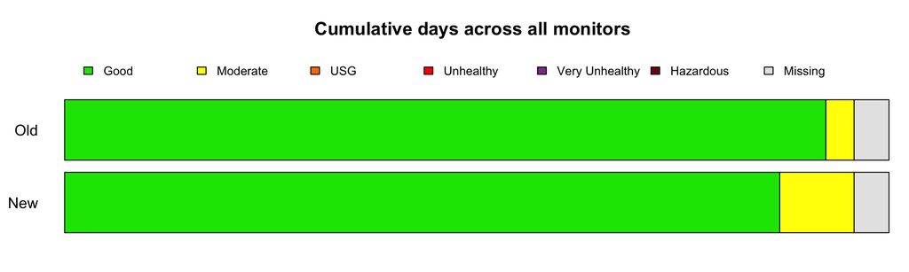

# 2020

**Using Old (2023) PM<sub>2.5</sub> NAAQS**

|  | Good | Moderate | USG | Unhealthy | Very Unhealthy | Hazardous | Missing |
| --- | --- | --- | --- | --- | --- | --- | --- |
| Wenatchee | 98 | 6 | 1 | 6 | 2 | 2 | 7 |
| Leavenworth | 103 | 9 | 2 | 6 | 2 | 0 | 0 |
| Twisp | 104 | 9 | 2 | 5 | 2 | 0 | 0 |
| Winthrop | 105 | 7 | 2 | 6 | 2 | 0 | 0 |
| Omak | 88 | 19 | 1 | 5 | 4 | 2 | 3 |
| Chelan | 105 | 5 | 1 | 7 | 2 | 2 | 0 |

**Using New (2024) PM<sub>2.5</sub> NAAQS**

|  | Good | Moderate | USG | Unhealthy | Very Unhealthy | Hazardous | Missing |
| --- | --- | --- | --- | --- | --- | --- | --- |
| Wenatchee | 87 | 17 | 1 | 6 | 1 | 3 | 7 |
| Leavenworth | 93 | 19 | 2 | 6 | 2 | 0 | 0 |
| Twisp | 95 | 18 | 2 | 5 | 2 | 0 | 0 |
| Winthrop | 94 | 18 | 2 | 5 | 3 | 0 | 0 |
| Omak | 70 | 37 | 1 | 5 | 2 | 4 | 3 |
| Chelan | 99 | 11 | 1 | 6 | 2 | 3 | 0 |

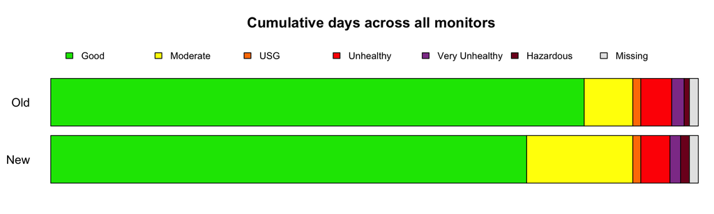

# 2021

**Using Old (2023) PM<sub>2.5</sub> NAAQS**

|  | Good | Moderate | USG | Unhealthy | Very Unhealthy | Hazardous | Missing |
| --- | --- | --- | --- | --- | --- | --- | --- |
| Wenatchee | 113 | 5 | 2 | 2 | 0 | 0 | 0 |
| Leavenworth | 88 | 7 | 1 | 3 | 0 | 0 | 23 |
| Twisp | 79 | 21 | 6 | 14 | 2 | 0 | 0 |
| Winthrop | 76 | 23 | 2 | 11 | 8 | 1 | 1 |
| Omak | 49 | 54 | 11 | 5 | 3 | 0 | 0 |
| Chelan | 109 | 8 | 3 | 2 | 0 | 0 | 0 |

**Using New (2024) PM<sub>2.5</sub> NAAQS**

|  | Good | Moderate | USG | Unhealthy | Very Unhealthy | Hazardous | Missing |
| --- | --- | --- | --- | --- | --- | --- | --- |
| Wenatchee | 107 | 11 | 2 | 2 | 0 | 0 | 0 |
| Leavenworth | 83 | 12 | 1 | 3 | 0 | 0 | 23 |
| Twisp | 64 | 36 | 6 | 12 | 4 | 0 | 0 |
| Winthrop | 61 | 38 | 2 | 8 | 10 | 2 | 1 |
| Omak | 31 | 72 | 11 | 5 | 3 | 0 | 0 |
| Chelan | 100 | 17 | 3 | 2 | 0 | 0 | 0 |

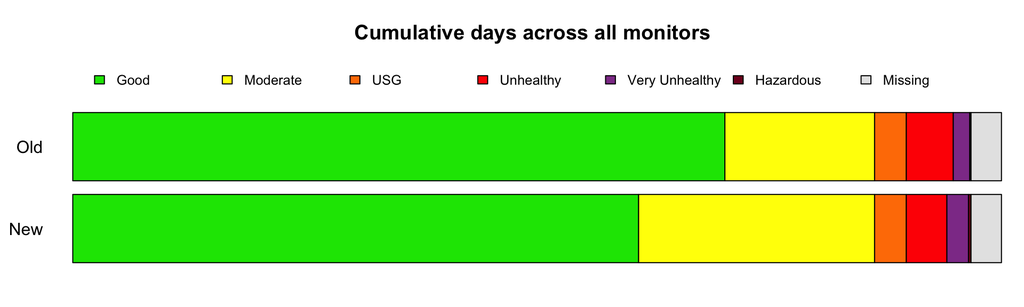

# 2022

**Using Old (2023) PM<sub>2.5</sub> NAAQS**

|  | Good | Moderate | USG | Unhealthy | Very Unhealthy | Hazardous | Missing |
| --- | --- | --- | --- | --- | --- | --- | --- |
| Wenatchee | 77 | 24 | 8 | 13 | 0 | 0 | 0 |
| Leavenworth | 65 | 26 | 7 | 12 | 1 | 0 | 11 |
| Twisp | 81 | 31 | 2 | 0 | 1 | 0 | 7 |
| Winthrop | 89 | 32 | 0 | 0 | 1 | 0 | 0 |
| Omak | 80 | 34 | 2 | 0 | 0 | 0 | 6 |
| Chelan | 80 | 31 | 1 | 0 | 1 | 0 | 9 |

**Using New (2024) PM<sub>2.5</sub> NAAQS**

|  | Good | Moderate | USG | Unhealthy | Very Unhealthy | Hazardous | Missing |
| --- | --- | --- | --- | --- | --- | --- | --- |
| Wenatchee | 73 | 28 | 8 | 13 | 0 | 0 | 0 |
| Leavenworth | 60 | 30 | 8 | 12 | 1 | 0 | 11 |
| Twisp | 73 | 39 | 2 | 0 | 1 | 0 | 7 |
| Winthrop | 78 | 43 | 0 | 0 | 1 | 0 | 0 |
| Omak | 59 | 55 | 2 | 0 | 0 | 0 | 6 |
| Chelan | 70 | 41 | 1 | 0 | 1 | 0 | 9 |

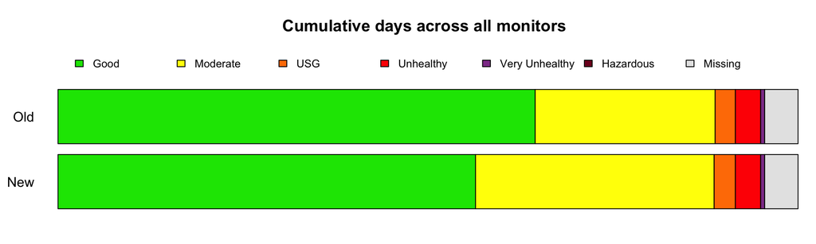